# Getting Started With Binomial Package

Zhe Chen

2019-05-03

## Binomial

The package “binomial” is an implementation for computing the probability of a binomial random variable, summarizing its related statistics and visualizing the probability distribution and cumulative probability distribution.

## Functions of measure

You can use the following functions to get the mean, variance, mode, skewness and kurtosis of a binomial distribution with specified trials and probability.

```r
#mean
bin_mean(10, 0.3)
```

```
#> [1] 3
```

```r
#variance
bin_variance(10, 0.3)
```

```
#> [1] 2.1
```

```r
#mode
bin_mode(10, 0.3)
```

```
#> [1] 3
```

```r
#skewness
bin_skewness(10, 0.3)
```

```
#> [1] 0.2760262
```

```r
#kurtosis
bin_kurtosis(10, 0.3)
```

```
#> [1] -0.1238095
```

## Function bin_choose()

You can use function bin_choose() to compute the number of combinations in which k successes can occur in n trials.

```r
bin_choose(n = 5, k = 2)
```

```
#> [1] 10
```

## Function bin_probability()

You can use function bin_probability() to compute the probability of getting k successes in n trials with specific probability of success.

```r
bin_probability(success=3,trials=5,prob=0.5)
```

```
#> [1] 0.3125
```

## Creating a binomial random variable object

The function bin_variable() gives you an object of class “binvar”, that is, a binomial random variable object.

```r
bin1<-bin_variable(trials=5,prob=0.5)
bin1
```

```
#> "Binomial variable"
#>
#> Paramaters
#> - number of trials:  5
#> - prob of success:  0.5
```

## Show the summary of binomial variable

Function `summary()` gives you a summary of parameters and measures of a binomial variable object.

```r
summary(bin1)
```

```
#> "Summary Binomial"
#>
#> Paramaters
#> - number of trials:  5
#> - prob of success:  0.5
#>
#> Measures
#> - mean    :  2.5
#> - variance:  1.25
#> - mode    :  3 2
#> - skewness:  0
#> - kurtosis:  -0.4
```

## Show the table of binomial distribution

You can use the function bin_distribution() to show a table of binomial distribution, where the first column is sucesses and the second column is probability.

```r
dist1=bin_distribution(trials=5,prob=0.5)
dist1
```

```
#>   success probability
#> 1       0     0.03125
#> 2       1     0.15625
#> 3       2     0.31250
#> 4       3     0.31250
#> 5       4     0.15625
#> 6       5     0.03125
```

## Show the table of cumulative distribution

You can use the function bin_cumulative() to return a data frame with both the probability distribution and the cumulative probabilities (sucesses in the first column, probability in the second column, and cumulative in the third column).

```r
dist2=bin_cumulative(trials=5,prob=0.5)
dist2
```

```
#>   success probability cumulative
#> 1       0     0.03125    0.03125
#> 2       1     0.15625    0.18750
#> 3       2     0.31250    0.50000
#> 4       3     0.31250    0.81250
#> 5       4     0.15625    0.96875
#> 6       5     0.03125    1.00000
```

## Plotting binomial distribution

Method plot.bindis() shows the barplot to display the probability histogram of a binomial distribution object “bindis”.

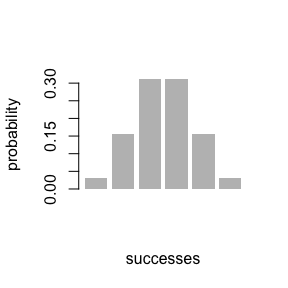

```r
# plotting binomial probability distribution
dist1=bin_distribution(trials=5,prob=0.5)
plot(dist1)
```

Method plot.bincum() shows the plot of cumulative distribution in an object “bincum”.

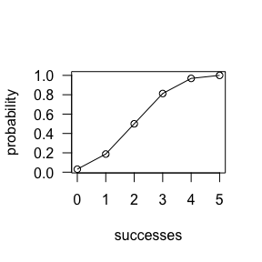

```r
# plotting binomial cumulative distribution
dist2 <- bin_cumulative(trials = 5, prob = 0.5)
plot(dist2)
```